# Identifying effective climate policies in Austria: a reverse-causal analysis

March 2023

## Introduction

## My motivation

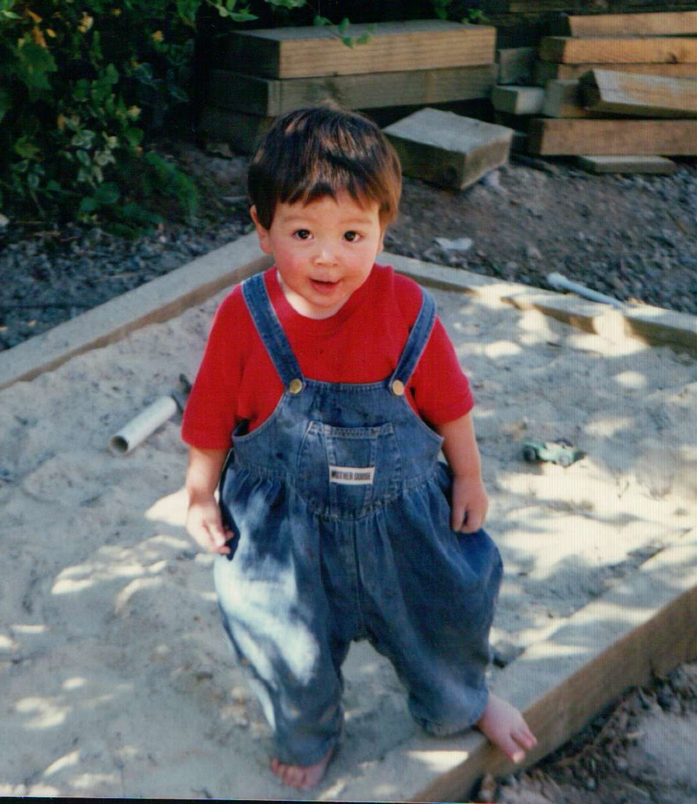

**My quest to find effective climate action**

- A love for nature
- **Australia:** a land of fires and floods
- **Activism:** Australian Youth Climate Coalition
- **Small scale action:** University Sustainability Office
- **Education:** Bachelors in Sustainability Science
- **Technology:** Working in Renewable Energy Innovation
- **Research:** Climate Plan for Austria

*“Policy is the most effective tool we have to fight climate change.”*

## What makes good climate policy?

*“Under the European climate law, EU countries must cut greenhouse gas emissions by at least 55% by 2030. Their goal is to make the EU climate neutral by 2050.”*

- Need to identify effective climate policy (as economists, we love efficiency)
- Limited resources: time and money
- Dissonance between targets and policies
- Need to evaluate policy in a non-biased way

*What does all of this mean for Austria?*

## GHG emissions in Austria

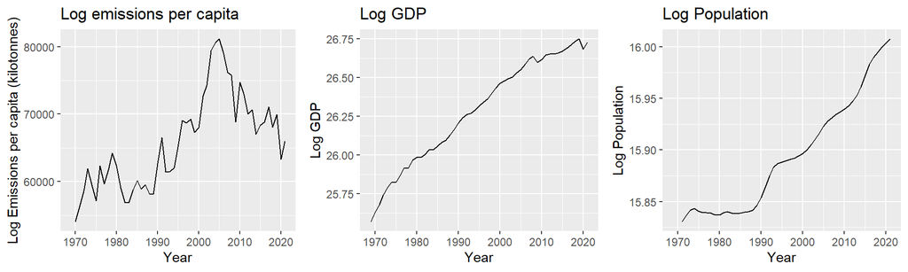

Emissions per capita, GDP and Population in Austria

## GHG emissions in Austria

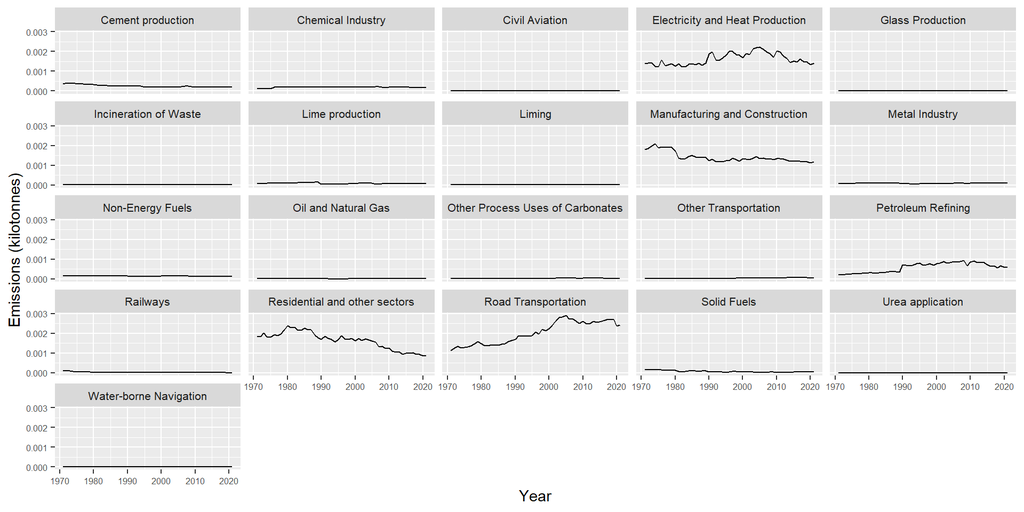

Emissions per capita by sector

## GHG emissions in Austria

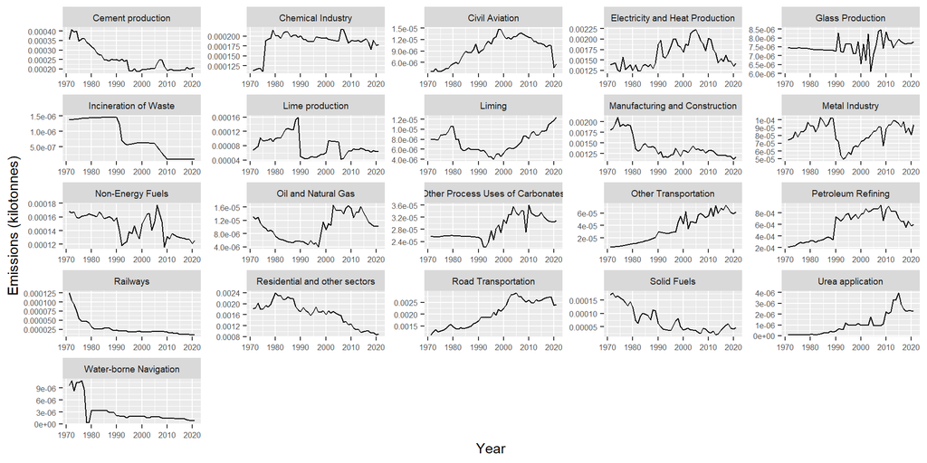

Emissions per capita by sector

## Methodology

## Policy evaluation: identifying effective climate policy

**Standard policy evaluation**

- Identify effects-of-causes of single, known policies
- Difficult to isolate individual policies in a real-world setting

**Reverse-causal policy evaluation**

- An agnostic approach to policy evaluation for policy mixes
- Identify a-priori unknown or underappreciated interventions

**An application of Koch et al. (2022)**

- *“Attributing agnostically-detected large reductions in road* \(CO_2\) emissions to policy mixes”
- What do I do differently? Focus on Austria, on all sectors
- Identify structural breaks in emissions, not accounted for by GDP or population, using machine learning
- Attribute breaks to policies, using emissions policy databases

## Data

Core datasets:

- **\(CO_2\) emissions**: combination of EDGAR (Emissions Database for Global Atmospheric Research) and International Energy Agencies (IEA) databases
- **Population and GDP**: World Bank, World Development Indicators

Policy databases:

- **The IEA’s Policies and Measures Database**: past, existing, or planned climate and energy policies. Data is collected from governments, international organisations, and IEA analyses, and governments can review the provided information periodically.
- **IEA/IRENA Renewable Energy Policies and Measures Database**: a joint database of renewable energy policies and measures of the IEA and IRENA.
- **The National Communications to the UNFCCC secretariat**: obligatory for our sample countries to submit regularly.

## Results

## Structural breaks

**Table 1. Negative structural breaks in Austrian emissions**

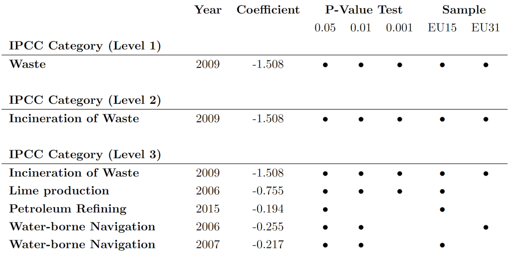

## Structural breaks

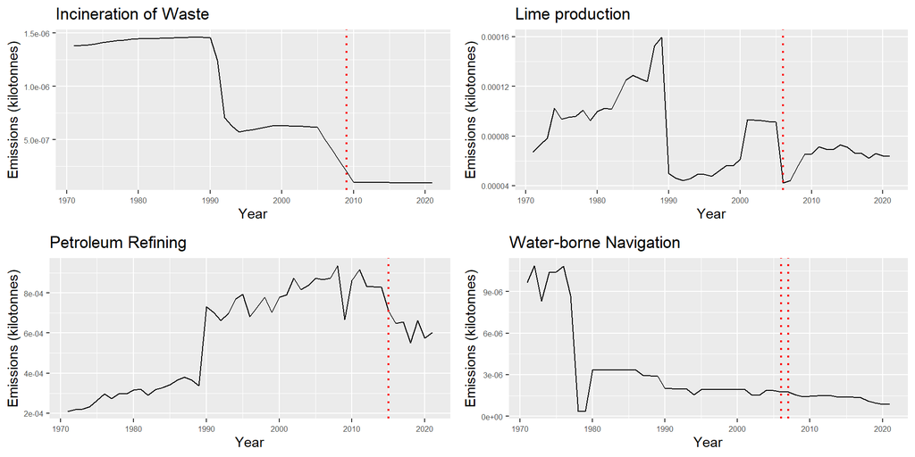

Emissions per capita for sectors with structural breaks

## Structural breaks

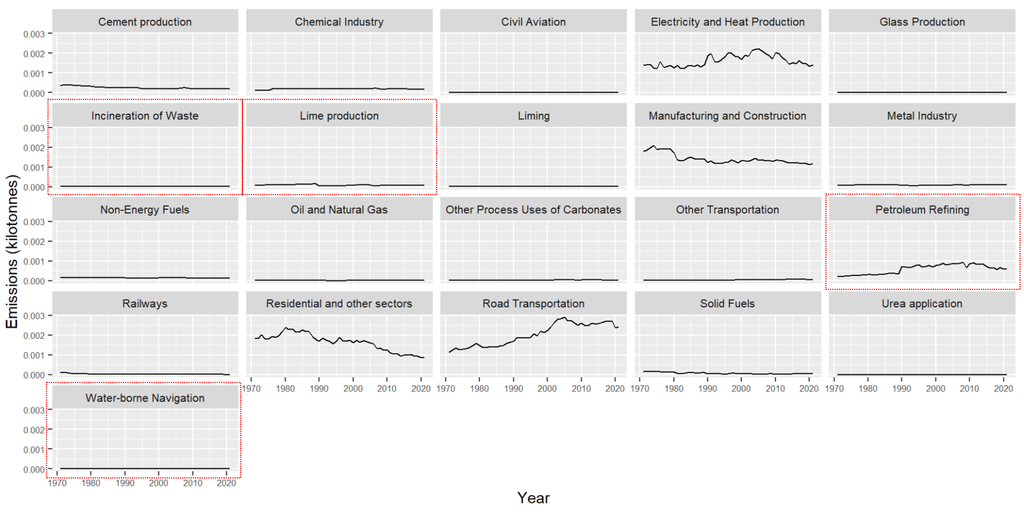

Emissions per capita by sector

## Policy attribution

**Incineration of waste (2009)**

- Austrian Climate Change Strategy (2007)
- klima:aktiv Climate Strategy 2008 - 2012
- Ökostromverordnung 2009 (2009 feed-in tariffs for green electricity)
- Ökostromverordnung (feed-in tariffs) (2010). FiT for Landfill gas, biomass and biogas, leading to waste being diverted from landfill. 15 year FiTs.

**Lime production (2006)**

- Emission Trading System implemented in 2005, which affected mineral industries
- Expert System for an Intelligent Supply of Thermal Energy in Industry (EINSTEIN) (2007) is a methodology for the implementation of a holistic integral approach to thermal energy auditing in industry.
- Climate and Energy Fund (2007). The Climate Fund supports actions taken in the areas of **buildings**, mobility, production and energy supply.

**Petroleum refining (2015)**

**Water-borne navigation (2006-2007)**

- Austrian Climate Change Strategy (2007)
- klima:aktiv programme Renewable Energy (2005). Includes provisions for biogas and boimaethane for transport use.
- Klimaaktiv mobil (2007). Between 2007 and 2016 more than 6,600 green mobility projects have beeninitiated. This made annual savings of 610,000 tonnes of CO2 possible. In 2015,the BMLFUW allocated approx. 9 million EUR for klimaaktiv mobil funding andabout 2 million EUR for consulting, information and education programs, providedby the ministry, the Climate and Energy Fund and the National EnvironmentalSupport Scheme.